# Modeling with tidymodels in R

#### Random Grid Search

The most common method of hyperparameter tuning is grid search. This method creates a tuning grid with unique combinations of hyperparameter values and uses cross validation to evaluate their performance. **The goal of hyperparameter tuning is to find the optimal combination of values for maximizing model performance.**

```r
# - Hyperparameter tuning with grid search

set.seed(456)

dt_grid <- grid_random(parameters(dt_tune_model),
                       size = 5)

dt_grid
```

```
## # A tibble: 5 × 3
##   cost_complexity tree_depth min_n
##             <dbl>      <int> <int>
## 1        6.40e-10         12    10
## 2        7.85e- 9         11    16
## 3        3.95e- 4          9    27
## 4        4.67e- 3         14    20
## 5        1.25e- 3         15    24
```

```r
# - Hyperparameter tuning

dt_tuning <- loans_tune_wkfl %>%
  tune_grid(resamples = loans_folds,
            grid = dt_grid,
            metrics = loans_metric)


# - View Results

dt_tuning %>%
  collect_metrics()
```

```
## # A tibble: 15 × 9
##    cost_complexity tree_depth min_n .metric .estim…¹  mean     n std_err .config
##              <dbl>      <int> <int> <chr>   <chr>    <dbl> <int>   <dbl> <chr>
##  1        6.40e-10         12    10 roc_auc binary   0.797    10  0.0140 Prepro…
##  2        6.40e-10         12    10 sens    binary   0.703    10  0.0295 Prepro…
##  3        6.40e-10         12    10 spec    binary   0.768    10  0.0231 Prepro…
##  4        7.85e- 9         11    16 roc_auc binary   0.818    10  0.0175 Prepro…
##  5        7.85e- 9         11    16 sens    binary   0.687    10  0.0276 Prepro…
##  6        7.85e- 9         11    16 spec    binary   0.778    10  0.0178 Prepro…
##  7        3.95e- 4          9    27 roc_auc binary   0.836    10  0.0158 Prepro…
##  8        3.95e- 4          9    27 sens    binary   0.663    10  0.0292 Prepro…
##  9        3.95e- 4          9    27 spec    binary   0.803    10  0.0258 Prepro…
## 10        4.67e- 3         14    20 roc_auc binary   0.831    10  0.0159 Prepro…
## 11        4.67e- 3         14    20 sens    binary   0.682    10  0.0207 Prepro…
## 12        4.67e- 3         14    20 spec    binary   0.835    10  0.0135 Prepro…
## 13        1.25e- 3         15    24 roc_auc binary   0.830    10  0.0140 Prepro…
## 14        1.25e- 3         15    24 sens    binary   0.655    10  0.0271 Prepro…
## 15        1.25e- 3         15    24 spec    binary   0.788    10  0.0208 Prepro…
## # … with abbreviated variable name ¹.estimator
```

```r
# - Collect detailed tuning results
dt_tuning_results <- dt_tuning %>%
  collect_metrics(summarize = FALSE)

dt_tuning_results
```

```
## # A tibble: 150 × 8
##    id     cost_complexity tree_depth min_n .metric .estimator .estimate .config
##    <chr>            <dbl>      <int> <int> <chr>   <chr>          <dbl> <chr>
##  1 Fold01        6.40e-10         12    10 sens    binary         0.615 Preproc…
##  2 Fold01        6.40e-10         12    10 spec    binary         0.829 Preproc…
##  3 Fold01        6.40e-10         12    10 roc_auc binary         0.815 Preproc…
##  4 Fold02        6.40e-10         12    10 sens    binary         0.615 Preproc…
##  5 Fold02        6.40e-10         12    10 spec    binary         0.6   Preproc…
##  6 Fold02        6.40e-10         12    10 roc_auc binary         0.763 Preproc…
##  7 Fold03        6.40e-10         12    10 sens    binary         0.76  Preproc…
##  8 Fold03        6.40e-10         12    10 spec    binary         0.775 Preproc…
##  9 Fold03        6.40e-10         12    10 roc_auc binary         0.806 Preproc…
## 10 Fold04        6.40e-10         12    10 sens    binary         0.76  Preproc…
## # … with 140 more rows
```

```r
# - Explore detailed ROC AUC results for each fold

dt_tuning_results %>%
  filter(.metric == 'roc_auc') %>%
  group_by(id) %>%
  summarize(min_roc_auc = min(.estimate),
            median_roc_auc = median(.estimate),
            max_roc_auc = max(.estimate))
```

```
## # A tibble: 10 × 4
##    id     min_roc_auc median_roc_auc max_roc_auc
##    <chr>        <dbl>          <dbl>       <dbl>
##  1 Fold01       0.776          0.847       0.912
##  2 Fold02       0.763          0.781       0.794
##  3 Fold03       0.784          0.795       0.857
##  4 Fold04       0.828          0.846       0.865
##  5 Fold05       0.724          0.764       0.800
##  6 Fold06       0.760          0.891       0.893
##  7 Fold07       0.729          0.782       0.796
##  8 Fold08       0.816          0.85        0.861
##  9 Fold09       0.860          0.89        0.926
## 10 Fold10       0.814          0.826       0.86
```

#### Selecting the best model

To incorporate hyperparameter tuning into your modeling process, an optimal hyperparameter combination must be selected based on the average value of a performance metric. Then you will be able to finalize your tuning workflow and fit your final model.

```r
# - Display the 5 best performing hyperparameter combinations from your tuning results based on the area under the ROC curve.

dt_tuning %>%
  show_best(metric = "roc_auc", n = 5)
```

```
## # A tibble: 5 × 9
##   cost_complexity tree_depth min_n .metric .estima…¹  mean     n std_err .config
##             <dbl>      <int> <int> <chr>   <chr>     <dbl> <int>   <dbl> <chr>
## 1        3.95e- 4          9    27 roc_auc binary    0.836    10  0.0158 Prepro…
## 2        4.67e- 3         14    20 roc_auc binary    0.831    10  0.0159 Prepro…
## 3        1.25e- 3         15    24 roc_auc binary    0.830    10  0.0140 Prepro…
## 4        7.85e- 9         11    16 roc_auc binary    0.818    10  0.0175 Prepro…
## 5        6.40e-10         12    10 roc_auc binary    0.797    10  0.0140 Prepro…
## # … with abbreviated variable name ¹.estimator
```

```r
# - Choosing the best model

best_dt_model <- dt_tuning %>%
  select_best(metric = "roc_auc")

best_dt_model
```

```
## # A tibble: 1 × 4
##   cost_complexity tree_depth min_n .config
##             <dbl>      <int> <int> <chr>
## 1        0.000395          9    27 Preprocessor1_Model3
```

```r
# - Finalize the workflow

final_loans_wkfl <- loans_tune_wkfl %>%
  finalize_workflow(best_dt_model)

final_loans_wkfl
```

```
## ══ Workflow ════════════════════════════════════════════════════════════════════
## Preprocessor: Recipe
## Model: decision_tree()
##
## ── Preprocessor ────────────────────────────────────────────────────────────────
## 3 Recipe Steps
##
## • step_corr()
## • step_normalize()
## • step_dummy()
##
## ── Model ───────────────────────────────────────────────────────────────────────
## Decision Tree Model Specification (classification)
##
## Main Arguments:
##   cost_complexity = 0.000395000288718773
##   tree_depth = 9
##   min_n = 27
##
## Computational engine: rpart
```

```r
# - Our workflow is now ready for model fitting and prediction on new data sources!
```

#### Training final workflow

```r
# - Train finalized decision tree workflow

loans_final_fit <- final_loans_wkfl %>%
  last_fit(split = loans_split)

# - View performance metrics

loans_final_fit %>%
  collect_metrics()
```

```
## # A tibble: 2 × 4
##   .metric  .estimator .estimate .config
##   <chr>    <chr>          <dbl> <chr>
## 1 accuracy binary         0.813 Preprocessor1_Model1
## 2 roc_auc  binary         0.880 Preprocessor1_Model1
```

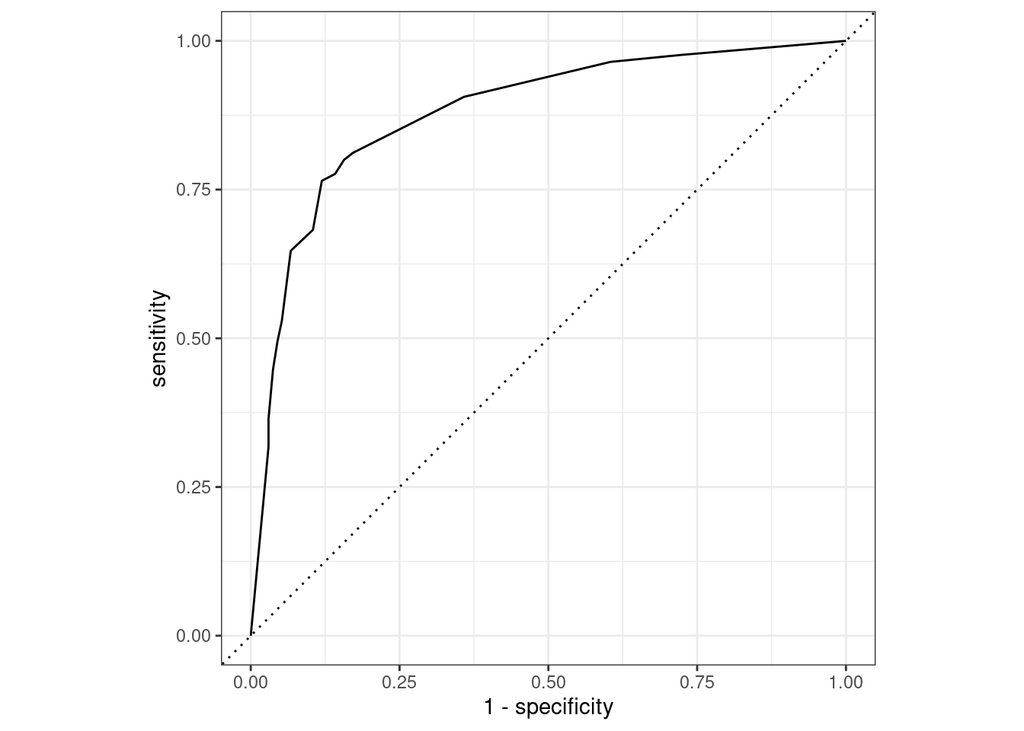

```r
# - Create an ROC curve
loans_final_fit %>%
  # - Collect predictions
  collect_predictions() %>%
  # - Calculate ROC curve metrics
  roc_curve(truth = loan_default, .pred_yes) %>%
  # - Plot the ROC curve
  autoplot()
```

```r
# -  We were able to train your finalized workflow with last_fit() and generate predictions on the test data.
```